# Function Iterations in R

Nick Holt, PhD3r (@NA_Holt)

August 29, 2017

*The contents of this document were presented as a talk to the Louisville R Users Group Meetup. Some of the content presented below was adapted from R for Data Science by Hadley Wickham, which is an excellent resource. Specifically, Chapter 17 demonstrates the strengths of the purrr package, and I highly recommend the exercises throughout the chapter if you would like practice on this topic.*

## Writing Functions in R

Programming *is* problem solving

- beginning state: data you have (input)
- end state: what you need (output)

R has lots of functions that can take your input (data) and give you useful output (transformed data, models, etc.)

- these functions are just “problems” that someone else has already solved

We often encounter situations where there is not a predefined function that meets our needs. In these cases, we need to create code that will take our input and give us the needed output. This is the essence of programming: creating customized, repeatable solutions to novel input -> output problems.

Programming a PB&J: https://www.youtube.com/watch?v=cDA3_5982h8

### Writing a Basic Function

Here is the skeleton code of an R function:

```r
function_name <- function(arg1, arg2) {
        # some actions that solve
        # the problem and produce
        # the desired output
}
```

Using this framework, here is a simple function that takes a numeric vector as input, calculates the mean, and returns the value for the mean:

```r
calculate_mean <- function(input) {
        average <- sum(input)/length(input)
        return(average)
}

calculate_mean(mtcars[,1])
```

```
## [1] 20.09062
```

## Basic Iteration in R

There are 3 kinds of loops in R:

- repeat()
- while()
- for()

In R, many functions are vectorized, so we don’t need these loops as often compared to other programming languages, but they are still useful.

### repeat()

**repeat()** is the easiest loop to master.

- all it does is execute the same code over and over until you tell it to stop
- in other languages, it often goes by the name **do while**
- the following example will execute until you press Escape, quit R, your laptop runs out of electricity, or the universe ends (whichever comes first)

```r
repeat {
        message("Just keep swimming...")
        Sys.sleep(1)
}
```

In general, I would prefer my code to complete before the end of time. We can break out of an infinte loop in R by including a **break** statement. We can also include a **next** statement when we would like to skip the rest of the current iteration and start at the beginning of the next iteration.

### while()

**while** loops are like backward repeat loops.

- Instead of executing some code and then checking to see if the loop should end, **while** loops check a conditional statement first and then decide whether or not to execute
- Since the state check happens first, it is possible that the loop will never be executed if the conditions are not met

### for()

**for** loops are the third type of loop in R, and are typically used only when you know exactly how many times you want the code to repeat.

- **for** loops take an index (i) and assign it successive values from a sequence or vector
- these loops are most commonly used for iterating an operation over elements of an object (matrix, list, data frame, etc.)
- many people claim that R’s **for** loops are almost always going to run more slowly than their true vectorized counterparts (apply family), but this isn’t necessarily the case (more on that later)

## Beyond for loops (the apply family)

There are predefined loop “functions” in R allow you to execute loop-like behaviors in a compact way

- these functions typically have the word “apply” in them

### lapply()

**lapply** is the simplest and most commonly used loop function

- **lapply** stands for “list apply”
- the function takes a list and a function as inputs, then it applies the function to each element of the list, and return another list of results as output

The example below demonstrates the difference between using a for loop or lapply to solve a simple task like finding the mean of each column of the mtcars dataset.

```r
# for loop to calculate the mean of every column in mtcars
data <- mtcars
output <- vector("double", ncol(data))
for(i in seq_along(data)){
        output[[i]] <- mean(mtcars[[i]])
}
print(output)
```

```
##  [1]  20.090625   6.187500 230.721875 146.687500   3.596563   3.217250
##  [7]  17.848750   0.437500   0.406250   3.687500   2.812500
```

```r
# here is the same loop implemented using lapply
lapply(data, mean)
```

```
## $mpg
## [1] 20.09062
##
## $cyl
## [1] 6.1875
##
## $disp
## [1] 230.7219
##
## $hp
## [1] 146.6875
##
## $drat
## [1] 3.596563
##
## $wt
## [1] 3.21725
##
## $qsec
## [1] 17.84875
##
## $vs
## [1] 0.4375
##
## $am
## [1] 0.40625
##
## $gear
## [1] 3.6875
##
## $carb
## [1] 2.8125
```

Notice that the result of the lapply call is a list. This format is not always ideal.

### sapply()

When we want to return a vector, we can use a variant of lapply called **sapply**

- **sapply** stands for “simplifying list apply”
- **sapply** takes a list and a function as arguments, just like lapply
- **sapply** will try to automatically simplify the resulting output into a vector instead of a list when possible

```r
# here is the same loop implemented using lapply
sapply(data, mean)
```

```
##        mpg        cyl       disp         hp       drat         wt
##  20.090625   6.187500 230.721875 146.687500   3.596563   3.217250
##       qsec         vs         am       gear       carb
##  17.848750   0.437500   0.406250   3.687500   2.812500
```

### apply()

**apply** is the namesake function of the family, and is used to evaluate a function over the margins (dimensions) of an array

general form: **apply(array, margin, function)**

```r
# using apply to calculate the means of the columns of mtcars
apply(data, 2, mean)
```

```
##        mpg        cyl       disp         hp       drat         wt
##  20.090625   6.187500 230.721875 146.687500   3.596563   3.217250
##       qsec         vs         am       gear       carb
##  17.848750   0.437500   0.406250   3.687500   2.812500
```

The **apply** function takes the same inputs as the other functions mentioned previously, but needs a margin argument inbetween the data and function arguments.

Margin arguments:

- margin = 1 is used to evaluate a function row-wise
- margin = 2 is used to evaluate a function column-wise

Examples:

- rowSums = apply(x, 1, sum)
- rowMeans = apply(x, 1, mean)
- colSums = apply(x, 2, sum)
- colMeans = apply(x, 2, mean)

## The advantages of functionals over for loops

Let’s think about the for loop we wrote to calculate the mean of each column in mtcars:

```r
# for loop to calculate the mean of every column in mtcars
data <- mtcars
output <- vector("double", ncol(data))
for(i in seq_along(data)){
        output[[i]] <- mean(mtcars[[i]])
}
```

We can turn this into a general function that can be called on any data frame.

```r
# function to calculate the mean of every column in a df
col_mean <- function(df) {
        output <- vector("double", ncol(df))
        for(i in seq_along(df)){
                output[[i]] <- mean(df[[i]])
        }
        output
}

col_mean(mtcars)
```

```
##  [1]  20.090625   6.187500 230.721875 146.687500   3.596563   3.217250
##  [7]  17.848750   0.437500   0.406250   3.687500   2.812500
```

Now, let’s imagine that we want to take the same approach and create similar functions that will give us the medians and standard deviations of columns in a data frame:

```r
# function to calculate the mean of every column in a df
col_mean <- function(df) {
        output <- vector("double", ncol(df))
        for(i in seq_along(df)){
                output[[i]] <- mean(df[[i]])
        }
        output
}

col_mean(mtcars)
```

```
##  [1]  20.090625   6.187500 230.721875 146.687500   3.596563   3.217250
##  [7]  17.848750   0.437500   0.406250   3.687500   2.812500
```

```r
# function to calculate the median of every column in a df
col_median <- function(df) {
        output <- vector("double", ncol(df))
        for(i in seq_along(df)){
                output[[i]] <- median(df[[i]])
        }
        output
}

col_median(mtcars)
```

```
##  [1]  19.200   6.000 196.300 123.000   3.695   3.325  17.710   0.000
##  [9]   0.000   4.000   2.000
```

```r
# function to calculate the sd of every column in a df
col_sd <- function(df) {
        output <- vector("double", ncol(df))
        for(i in seq_along(df)){
                output[[i]] <- sd(df[[i]])
        }
        output
}

col_sd(mtcars)
```

```
##  [1]   6.0269481   1.7859216 123.9386938  68.5628685   0.5346787
##  [6]   0.9784574   1.7869432   0.5040161   0.4989909   0.7378041
## [11]   1.6152000
```

We have copied and pasted our code and changed only a few characters in our code each time. While this approach produces three distinct functions that accomplish our goal, notice that we have repeated ourselves several times. As Hadley Wickham famously notes, this approach is problematic for a few reasons.

- Any time we copy and paste code, and then edit, we are adding unecessary steps that add room for errors. In the code above, we have to change the target function (mean, median, sd), and we need to change the function name, but you can imagine that as the code gets more complex, we need to make an increasingly larger number of edits at each copy/paste step. This echos the DRY principle: **Don’t Repeat Yourself.**
- Good code should be written for the human reader in mind. In the example above, we have accomplished our goal, but if a new user looked at the code, it would be difficult at first glance to understand the differences between the functions. They are so structurally similar that the important information (the differences) are not easy to discern. The code above emphasizes the loop structure, not the verbs that matter to the user.
- For an interesting illustration of the above arguments against the multiple for loop approach, here is a great rant about baking cupcakes by Hadley: https://www.youtube.com/watch?v=GyNqlOjhPCQ

**So, what is a better solution?**

We can take our original for loop and add a new argument for the function that we want to loop over the columns, like so:

```r
# function to apply a given function over the columns of a df
col_summary <- function(df, fun) {
        output <- vector("double", ncol(df))
        for(i in seq_along(df)){
                output[[i]] <- fun(df[[i]])
        }
        output
}

col_summary(mtcars, mean)
```

```
##  [1]  20.090625   6.187500 230.721875 146.687500   3.596563   3.217250
##  [7]  17.848750   0.437500   0.406250   3.687500   2.812500
```

```r
col_summary(mtcars, median)
```

```
##  [1]  19.200   6.000 196.300 123.000   3.695   3.325  17.710   0.000
##  [9]   0.000   4.000   2.000
```

```r
col_summary(mtcars, sd)
```

```
##  [1]   6.0269481   1.7859216 123.9386938  68.5628685   0.5346787
##  [6]   0.9784574   1.7869432   0.5040161   0.4989909   0.7378041
## [11]   1.6152000
```

We have written far fewer lines of code, accomplished the same goal, and reduced the chance of copy/paste errors or bugs. That’s really cool, and really powerful.

Let’s take a step back and think about what has actually happened in the code above. **We passed a function as an argument into another function?!**

This concept is exactly the reason why the apply family of functions exist, and the argument I have outlined above is the primary reason for their use over a series of for loops.

Next, we will demonstrate a modernized version of the apply family of functions that have been created in the tidyverse package called **purrr**. The advantages of **purrr** over the base R apply family of functions will be demonstrated below.

## Using purrr for Iteration

So far, we have talked about writing functions, iterating functions over data frames using for loops, and accomplishing the same goals with fewer lines of code using the apply family. **Purrr** is a library in the tidyverse that is designed to solve the problem of generalizing a function to every element in a list.

**Purrr** also works with the pipe character, %>%, to break down complex problems into managable pieces, which means that it plays nicely with other tidyverse packages.

Once you are comfortable with purrr, you will begin to write code that is much easier to read, especially after months away from a project.

### map()

```r
# Up until now we have been using base R, but purrr
# is a tidyverse function, so let's load the library
library(tidyverse)
```

**Purrr** contains a set of functions that all loop over a vector, apply a function to each element, and return output:

- **map()** loops over a vector and creates a list as output
- **map_lgl()** returns a logical vector
- **map_int()** returns an integer vector
- **map_dbl()** returns a double vector
- **map_chr()** returns a character vector

Advantages of map() family of function from purrr over for loops (according to Hadley):

- “Once you master these functions, you’ll find it takes much less time to solve iteration problems”
- “The chief benefit of using functions like map() is not speed, but clarity: they make your code easier to write and read”

We can accomplish the same output as the col_summary() for loop function that we wrote above using a map function. Because the desired output is a vector of doubles, we will use map_dbl():

```r
# remember we used this function to apply functions over the columns of a df:
col_summary <- function(df, fun) {
        output <- vector("double", ncol(df))
        for(i in seq_along(df)){
                output[[i]] <- fun(df[[i]])
        }
        output
}

col_summary(mtcars, mean)
```

```
##  [1]  20.090625   6.187500 230.721875 146.687500   3.596563   3.217250
##  [7]  17.848750   0.437500   0.406250   3.687500   2.812500
```

```r
col_summary(mtcars, median)
```

```
##  [1]  19.200   6.000 196.300 123.000   3.695   3.325  17.710   0.000
##  [9]   0.000   4.000   2.000
```

```r
col_summary(mtcars, sd)
```

```
##  [1]   6.0269481   1.7859216 123.9386938  68.5628685   0.5346787
##  [6]   0.9784574   1.7869432   0.5040161   0.4989909   0.7378041
## [11]   1.6152000
```

Here is the same idea implemented using map_dbl()

```r
# Using map_dbl() to get mean, median, & sd
map_dbl(mtcars, mean)
```

```
##        mpg        cyl       disp         hp       drat         wt
##  20.090625   6.187500 230.721875 146.687500   3.596563   3.217250
##       qsec         vs         am       gear       carb
##  17.848750   0.437500   0.406250   3.687500   2.812500
```

```r
map_dbl(mtcars, median)
```

```
##     mpg     cyl    disp      hp    drat      wt    qsec      vs      am
##  19.200   6.000 196.300 123.000   3.695   3.325  17.710   0.000   0.000
##    gear    carb
##   4.000   2.000
```

```r
map_dbl(mtcars, sd)
```

```
##         mpg         cyl        disp          hp        drat          wt
##   6.0269481   1.7859216 123.9386938  68.5628685   0.5346787   0.9784574
##        qsec          vs          am        gear        carb
##   1.7869432   0.5040161   0.4989909   0.7378041   1.6152000
```

Notice that the map functions preserve column names, which is a handy feature for readibilty of output.

We can use the pipe to make the map_dbl code even more readable:

```r
mtcars %>% map_dbl(mean)
```

```
##        mpg        cyl       disp         hp       drat         wt
##  20.090625   6.187500 230.721875 146.687500   3.596563   3.217250
##       qsec         vs         am       gear       carb
##  17.848750   0.437500   0.406250   3.687500   2.812500
```

All purrr functions are written in C, giving them a slight speed advantage over base R for loops (but not nearly as much of an advantage as some have made it out to be). We will run a little experiment later, but for now, here is a stackoverflow response from Hadley on the matter:

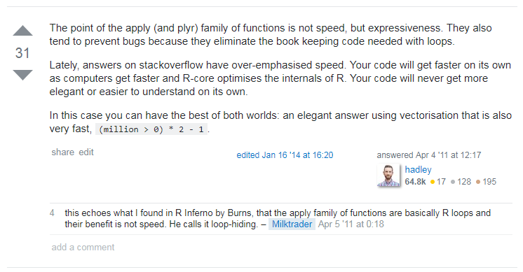

# Getting more advanced with purrr

We have seen that purrr can greatly reduce the amount of code we need to write to get the same output as a for loop. Just like the apply family, map() and its derivatives pass a function into another function.

However, we can take this functionality a step further (this is where things get really cool). We can create a vector of function names, and pass it as the function argument to map(). In doing so, we can accomplish the same task as the generalized col_summary loop, but in far fewer lines of code.

For example:

```r
# function to apply a given function over the columns of a df
col_summary <- function(df, fun) {
        output <- vector("double", ncol(df))
        for(i in seq_along(df)){
                output[[i]] <- fun(df[[i]])
        }
        output
}

col_summary(mtcars, mean)
```

```
##  [1]  20.090625   6.187500 230.721875 146.687500   3.596563   3.217250
##  [7]  17.848750   0.437500   0.406250   3.687500   2.812500
```

```r
col_summary(mtcars, median)
```

```
##  [1]  19.200   6.000 196.300 123.000   3.695   3.325  17.710   0.000
##  [9]   0.000   4.000   2.000
```

```r
col_summary(mtcars, sd)
```

```
##  [1]   6.0269481   1.7859216 123.9386938  68.5628685   0.5346787
##  [6]   0.9784574   1.7869432   0.5040161   0.4989909   0.7378041
## [11]   1.6152000
```

```r
# using the map framework, the for loop and function calls above become:
funs <- list(mean, median, sd)

funs %>%
        map(~ mtcars %>% map_dbl(.x))
```

```
## [[1]]
##        mpg        cyl       disp         hp       drat         wt
##  20.090625   6.187500 230.721875 146.687500   3.596563   3.217250
##       qsec         vs         am       gear       carb
##  17.848750   0.437500   0.406250   3.687500   2.812500
##
## [[2]]
##     mpg     cyl    disp      hp    drat      wt    qsec      vs      am
##  19.200   6.000 196.300 123.000   3.695   3.325  17.710   0.000   0.000
##    gear    carb
##   4.000   2.000
##
## [[3]]
##         mpg         cyl        disp          hp        drat          wt
##   6.0269481   1.7859216 123.9386938  68.5628685   0.5346787   0.9784574
##        qsec          vs          am        gear        carb
##   1.7869432   0.5040161   0.4989909   0.7378041   1.6152000
```

This approach works, because the second argument of map(), the argument for the function you want to apply to your data, is able to take on a formula, a character vector, or an integer vector.

One other handy property of map() is that it uses **…** to take additional arguments after the second function argument. This allows you to pass arguments of the function you are applying to your data. This is a little confusing at first glance, but look at the implementation:

```r
map_dbl(mtcars, mean, trim = 0.1)
```

```
##         mpg         cyl        disp          hp        drat          wt
##  19.6961538   6.2307692 222.5230769 141.1923077   3.5792308   3.1526923
##        qsec          vs          am        gear        carb
##  17.8276923   0.4230769   0.3846154   3.6153846   2.6538462
```

## Purrr in action on a large dataset

We are going to load in some data from an AirBnb Kaggle competition in order to do a demo on a large dataset. The data contains all AirBnb listings for the city of Seattle over the course of a year. There are many variables contained in a separate table that contain listing details (number of beds, room type, etc.)

Now that we have our data, lets take a look at what we are dealing with:

```r
glimpse(seattle)
```

```
## Observations: 1,393,570
## Variables: 95
## $ listing_id                       <int> 241032, 241032, 241032, 24103...
## $ date                             <date> 2016-01-04, 2016-01-05, 2016...
## $ available                        <chr> "t", "t", "f", "f", "f", "f",...
## $ price.x                          <dbl> 85, 85, NA, NA, NA, NA, NA, N...
## $ listing_url                      <chr> "https://www.airbnb.com/rooms...
## $ scrape_id                        <dbl> 2.01601e+13, 2.01601e+13, 2.0...
## $ last_scraped                     <date> 2016-01-04, 2016-01-04, 2016...
## $ name                             <chr> "Stylish Queen Anne Apartment...
## $ summary                          <chr> NA, NA, NA, NA, NA, NA, NA, N...
## $ space                            <chr> "Make your self at home in th...
## $ description                      <chr> "Make your self at home in th...
## $ experiences_offered              <chr> "none", "none", "none", "none...
## $ neighborhood_overview            <chr> NA, NA, NA, NA, NA, NA, NA, N...
```

[output cut: 82 more lines]

Now I’m going to write a simple function that will create a table of all unique responses and calculate their rate of occurence in the dataset.

```r
response_pct <- function(vec) {
        vec <- as.character(vec)
        pct_vec <- data.frame(vec) %>%
                group_by(vec) %>%
                summarize(n = n()) %>%
                mutate(response_freq = n/sum(n))
        return(pct_vec)
}
```

Assuming that I want to create a table of results for every variable in seattle df, let’s check out the differences between for loop, apply family, and map implemetation.

To make things a little more interesting, let’s use system.time to run a little experiment to get a sense of how the different approaches differ in run time.

### for loop

```r
# using a for loop to loop through each column in the seattle data frame
output <- list()
system.time(
for(i in seq_along(seattle)) {
        resp_table <- response_pct(seattle[[i]])
        output <- c(output, resp_table)
}
)
```

```
##    user  system elapsed
##  102.29    3.02  118.88
```

### lapply()

```r
# using apply with the same function
system.time(
output <- lapply(seattle, response_pct)
)
```

```
##    user  system elapsed
##   98.16    1.98  103.69
```

### map()

```r
# using map with the same function
system.time(
output <- map(seattle, response_pct)
)
```

```
##    user  system elapsed
##   97.39    1.72   99.75
```

## Summary

Hopefully this walkthrough has demonstrated the strengths and weaknesses of different approaches to iteration in R. There are lots of additional details that allow advanced functionality in purrr. However, those features are outside the scope of this talk. Please feel free to let me know if you have any questions or ideas (nholt2@bellarmine.edu). Thanks!